# R course project

Viktoria Ivanova

2025-01-28

## Central Limit Theorem

Simulation of Central Limit Theorem for large numbers.

```r
central_limit_theorem <- function(i, n, p) {

  if(i < 1000 || i > 10000 || !is.integer(i)) {
    stop("Number of iterations must be integer between 1000 and 10000.")
  }

  if(n < 90 || n > 900 || n%%2 != 0 || !is.integer(n)) {
    stop("Size of simulation must be even integer between 90 and 900.")
  }

  if(p < 0 || p > 1 || !is.numeric(p)) {
    stop("Probability should be real number between 0 and 1.")
  }

  mu <- (1 - p)/ p
  sigma <- sqrt((1 - p)/ (p^2))
  vector_size <- n / 2

  result_vector <- numeric(i)

  for(curr_iteration in 1:i) {
    normal_distribution_vector <- rnorm(vector_size, mu, sigma)
    geom_distribution_vector <- rgeom(vector_size, p)

    concatenated_vectors <- c(normal_distribution_vector, geom_distribution_vector)
    shuffled_vector <- sample(concatenated_vectors)

    mean_shuffled <- mean(shuffled_vector)
    result_to_add <- ((mean_shuffled - mu) / sigma) * sqrt(n)

    result_vector[curr_iteration] <- result_to_add
  }

  return(result_vector)
}
```

Now, the CLT simulation will be tested with:  
-> 3000 iterations  
-> 150 size of vector  
-> 0.35 probability

```r
vector_central_limit_theorem <- central_limit_theorem(3000L, 150L, 0.35)
```

After calling the function, the mean value and the standard deviation can be printed:

```r
mean_res <- mean(vector_central_limit_theorem)
std_res <- sd(vector_central_limit_theorem)
```

```
## [1] "Mean: -0.0381858860. Standard deviation: 0.9920744999."
```

And to check that the values follow a normal distribution, we can use q-q plot:

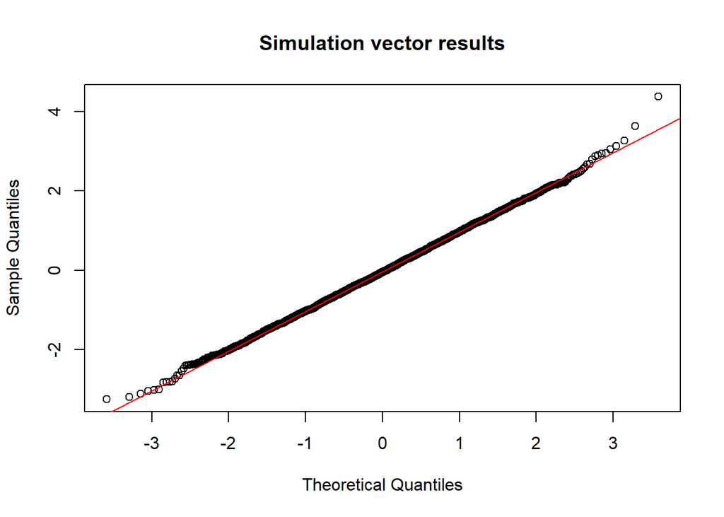

```r
qqnorm(vector_central_limit_theorem, main = "Simulation vector results")
qqline(vector_central_limit_theorem, col = "red")
```

Since the points on the graph look aligned on a stright line, we can conclude that the data is approximately normally distributed.

## Training mtcars dataset with linear regression model

Let’s include the needed libraries and the mtcars dataset:

library(tidymodels)  
library(corrplot)  
data(mtcars)

# Dataset analysation

First of all, let’s get familiar with the dataset ‘mtcars’ by making some observations.

```r
mtcars
```

```
##                      mpg cyl  disp  hp drat    wt  qsec vs am gear carb
## Mazda RX4           21.0   6 160.0 110 3.90 2.620 16.46  0  1    4    4
## Mazda RX4 Wag       21.0   6 160.0 110 3.90 2.875 17.02  0  1    4    4
## Datsun 710          22.8   4 108.0  93 3.85 2.320 18.61  1  1    4    1
## Hornet 4 Drive      21.4   6 258.0 110 3.08 3.215 19.44  1  0    3    1
## Hornet Sportabout   18.7   8 360.0 175 3.15 3.440 17.02  0  0    3    2
## Valiant             18.1   6 225.0 105 2.76 3.460 20.22  1  0    3    1
## Duster 360          14.3   8 360.0 245 3.21 3.570 15.84  0  0    3    4
## Merc 240D           24.4   4 146.7  62 3.69 3.190 20.00  1  0    4    2
## Merc 230            22.8   4 140.8  95 3.92 3.150 22.90  1  0    4    2
## Merc 280            19.2   6 167.6 123 3.92 3.440 18.30  1  0    4    4
## Merc 280C           17.8   6 167.6 123 3.92 3.440 18.90  1  0    4    4
## Merc 450SE          16.4   8 275.8 180 3.07 4.070 17.40  0  0    3    3
## Merc 450SL          17.3   8 275.8 180 3.07 3.730 17.60  0  0    3    3
## Merc 450SLC         15.2   8 275.8 180 3.07 3.780 18.00  0  0    3    3
## Cadillac Fleetwood  10.4   8 472.0 205 2.93 5.250 17.98  0  0    3    4
## Lincoln Continental 10.4   8 460.0 215 3.00 5.424 17.82  0  0    3    4
## Chrysler Imperial   14.7   8 440.0 230 3.23 5.345 17.42  0  0    3    4
## Fiat 128            32.4   4  78.7  66 4.08 2.200 19.47  1  1    4    1
## Honda Civic         30.4   4  75.7  52 4.93 1.615 18.52  1  1    4    2
## Toyota Corolla      33.9   4  71.1  65 4.22 1.835 19.90  1  1    4    1
## Toyota Corona       21.5   4 120.1  97 3.70 2.465 20.01  1  0    3    1
## Dodge Challenger    15.5   8 318.0 150 2.76 3.520 16.87  0  0    3    2
## AMC Javelin         15.2   8 304.0 150 3.15 3.435 17.30  0  0    3    2
## Camaro Z28          13.3   8 350.0 245 3.73 3.840 15.41  0  0    3    4
## Pontiac Firebird    19.2   8 400.0 175 3.08 3.845 17.05  0  0    3    2
## Fiat X1-9           27.3   4  79.0  66 4.08 1.935 18.90  1  1    4    1
## Porsche 914-2       26.0   4 120.3  91 4.43 2.140 16.70  0  1    5    2
## Lotus Europa        30.4   4  95.1 113 3.77 1.513 16.90  1  1    5    2
## Ford Pantera L      15.8   8 351.0 264 4.22 3.170 14.50  0  1    5    4
## Ferrari Dino        19.7   6 145.0 175 3.62 2.770 15.50  0  1    5    6
## Maserati Bora       15.0   8 301.0 335 3.54 3.570 14.60  0  1    5    8
## Volvo 142E          21.4   4 121.0 109 4.11 2.780 18.60  1  1    4    2
```

```r
dim(mtcars)
```

```
## [1] 32 11
```

```r
summary(mtcars)
```

```
##       mpg             cyl             disp             hp
##  Min.   :10.40   Min.   :4.000   Min.   : 71.1   Min.   : 52.0
##  1st Qu.:15.43   1st Qu.:4.000   1st Qu.:120.8   1st Qu.: 96.5
##  Median :19.20   Median :6.000   Median :196.3   Median :123.0
##  Mean   :20.09   Mean   :6.188   Mean   :230.7   Mean   :146.7
##  3rd Qu.:22.80   3rd Qu.:8.000   3rd Qu.:326.0   3rd Qu.:180.0
##  Max.   :33.90   Max.   :8.000   Max.   :472.0   Max.   :335.0
##       drat             wt             qsec             vs
##  Min.   :2.760   Min.   :1.513   Min.   :14.50   Min.   :0.0000
##  1st Qu.:3.080   1st Qu.:2.581   1st Qu.:16.89   1st Qu.:0.0000
##  Median :3.695   Median :3.325   Median :17.71   Median :0.0000
##  Mean   :3.597   Mean   :3.217   Mean   :17.85   Mean   :0.4375
##  3rd Qu.:3.920   3rd Qu.:3.610   3rd Qu.:18.90   3rd Qu.:1.0000
##  Max.   :4.930   Max.   :5.424   Max.   :22.90   Max.   :1.0000
##        am              gear            carb
##  Min.   :0.0000   Min.   :3.000   Min.   :1.000
##  1st Qu.:0.0000   1st Qu.:3.000   1st Qu.:2.000
##  Median :0.0000   Median :4.000   Median :2.000
##  Mean   :0.4062   Mean   :3.688   Mean   :2.812
##  3rd Qu.:1.0000   3rd Qu.:4.000   3rd Qu.:4.000
##  Max.   :1.0000   Max.   :5.000   Max.   :8.000
```

Next, let’s analyse the dependence between features by plotting the correlation heatmap of the dataset. It can be spotted that the dependent variables have correlation coefficient closer to {-1, 1} and the independent ones have coefficient close to 0.

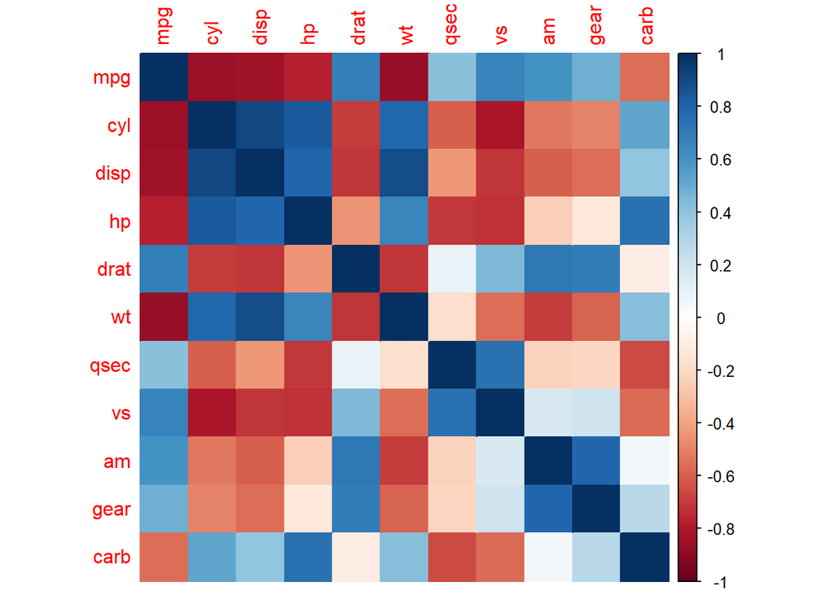

```r
cor_matrix <- cor(mtcars)
corrplot(cor_matrix, method = "color")
```

Now, we can step on the data preprocessing and creation of the Linear regression model. In the beginning, the data should be splitted with 30 training samples and 2 testing samples. This can be done with the initial_split() function:

```r
set.seed(123)
data_split <- initial_split(mtcars, prop = 30/32)
train_data <- training(data_split)
test_data <- testing(data_split)
```

With the training data we will instantiate a linear regression model and fit the data into it.

```r
linreg <- linear_reg()
linreg_fit <- linreg %>%
  fit(mpg ~ wt, data = train_data)
```

What family of functions would the fitted model be a member of? - first degree polynomial  
Now we can check the estimated coefficients for fˆ(x) by using the tidy() function:

```r
tidy(linreg_fit)
```

```
## # A tibble: 2 × 5
##   term        estimate std.error statistic  p.value
##   <chr>          <dbl>     <dbl>     <dbl>    <dbl>
## 1 (Intercept)    37.3      1.95      19.2  1.25e-17
## 2 wt             -5.36     0.586     -9.16 6.43e-10
```

The explicit form for fˆ(x) is: f^(wt) = -5.36 * wt + 37.3  
Let’s now plot the estimated model on the training dataset:

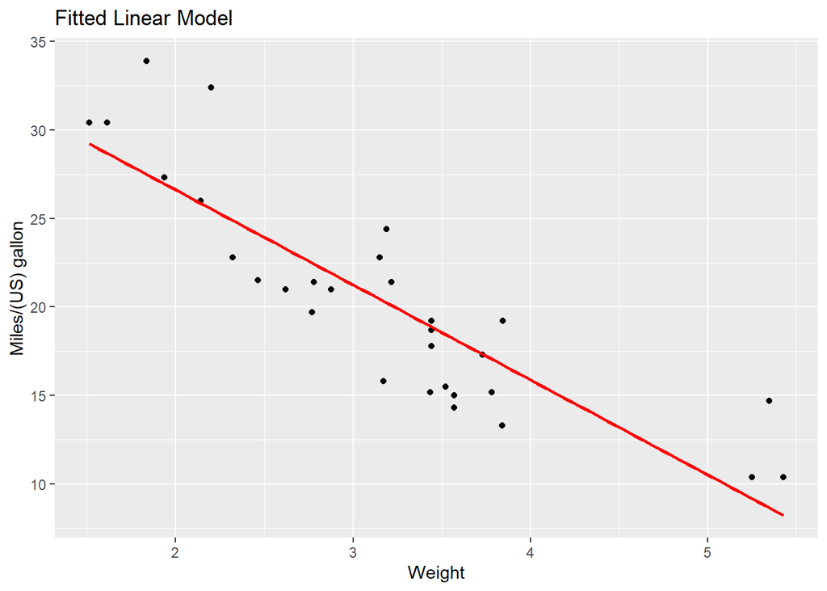

```r
ggplot(train_data, aes(x = wt, y = mpg)) +
  geom_point() +
  geom_smooth(method = "lm", se = FALSE, color = "red") +
  labs(title = "Fitted Linear Model",
       x = "Weight",
       y = "Miles/(US) gallon")
```

We can now predict the values for mpg on the unseen data - the testing set:

```r
predictions <- predict(linreg_fit, new_data = test_data)
predictions
```

```
## # A tibble: 2 × 1
##   .pred
##   <dbl>
## 1  18.8
## 2  15.5
```

In conclusion, we can check how well the model performs, based on the value of root_mean_squared_error:

```r
rmse_value <- augment(linreg_fit, new_data = test_data) %>%
          rmse(mpg, .pred)
rmse_value
```

```
## # A tibble: 1 × 3
##   .metric .estimator .estimate
##   <chr>   <chr>          <dbl>
## 1 rmse    standard       0.793
```

Based on the RMSE value, we can assume that the model performs pretty well.